# Pet Inclusive Housing Project Notes

## Logistic Regression Results

```
              rowname    OR 2.5 % 97.5 %
1         (Intercept)  0.12  0.09   0.16
2           MarketDFW  2.27  1.92   2.69
3   MarketLos Angeles  0.28  0.25   0.33
4  MarketPhiladelphia  0.56  0.48   0.66
5          MgmtCoTRUE  9.99  8.89  11.22
6          sizemedium  0.49  0.38   0.64
7           sizelarge  4.40  3.55   5.46
8      sizevery_large 33.64 26.63  42.48
9                age2  0.69  0.61   0.79
10               age3  0.70  0.62   0.80
11               age4  0.39  0.34   0.45
12               age5  0.55  0.47   0.65
13         SOCIO_QUI2  0.96  0.80   1.15
14         SOCIO_QUI3  0.80  0.67   0.95
15         SOCIO_QUI4  0.77  0.65   0.91
16         SOCIO_QUI5  0.50  0.42   0.58
```

## Odds Ratio Chart

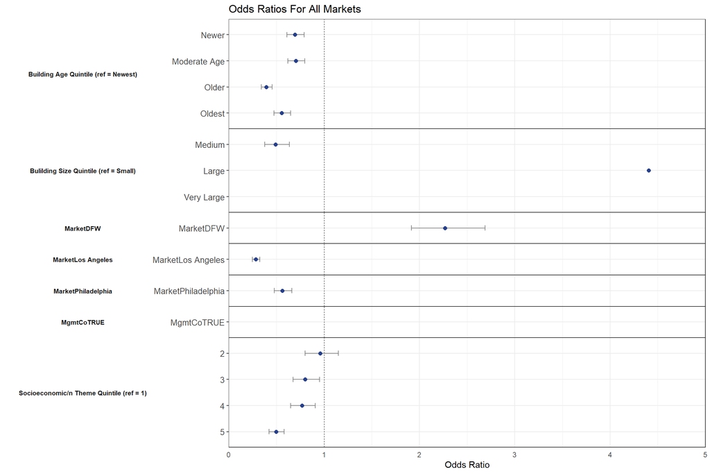

- Size Label Breakdown
  - 0-4 Units (Small)
  - 5-15 Units (Medium)
  - 16-100 Units (Large)
  - More than 100 Units (Very Large)
- Size bands were chosen based the Landlord Type Breakdown document further down
- Very large properties’ odds ratios outside limits of the chart
- Building Age Breakdown
  - 0-25 Years (Newest)
  - 26-46 Years (Newer)
  - 47-61 (Moderate Age)
  - 62-70 (Older)
  - 71-236 (Oldest)
- Building bands were chosen based on what would result in a equal count in each band.

## Extremely Strong Relationship

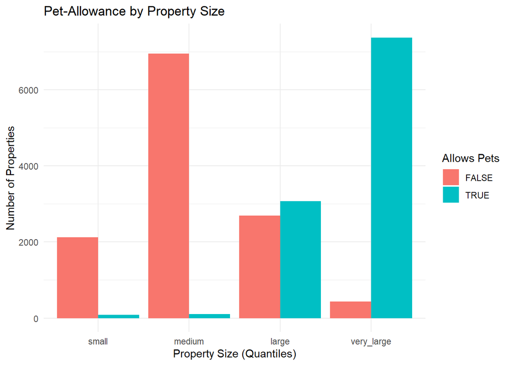

- Small and medium sized buildings are much more likely to not allow pets than large and very large buildings

## Landlord Type Breakdown

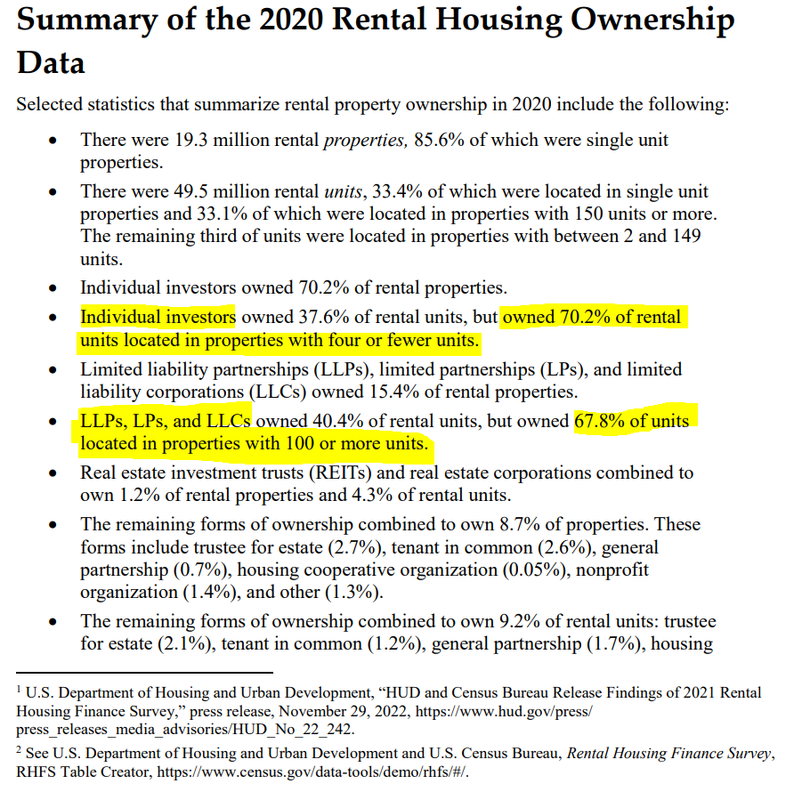

- Individual investors own a majority of units located in small properties while limited liability companies and partnerships own a majority of units in large properties

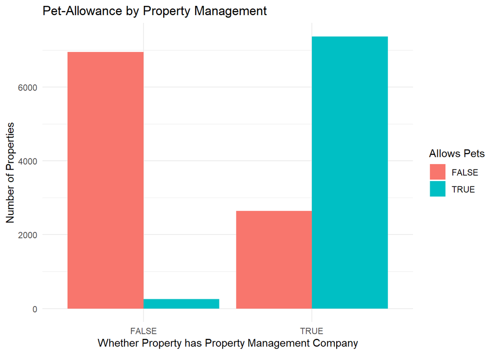

- A property being managed by a property management company also plays an impact as to whether the property allows pets or not.
- Properties are much more likely to not allow pets if they do not have a property management company.

## Bills - California

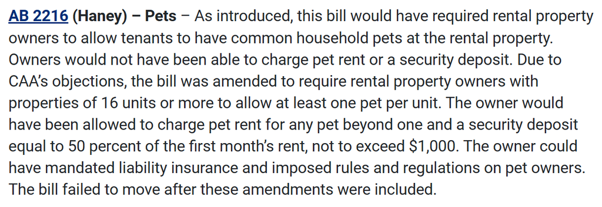

CAA = California Apartment Association

- A pet inclusive housing bill was introduced in California, but did not go through after objections from the CAA.

## Racial/Ethnicity Variable

- Close to being significant
- Confounding variable with Socioeconomic Status

## Race + Socioeconomic Chart

```
    Pearson's Chi-squared test

data:  chisq_table
X-squared = 12435, df = 16, p-value < 2.2e-16
```

```
Cramer V
  0.3375
```

[figure not shown]

- A Cramer V value of 0.34 interprets as a moderately strong relationship between the Race and Socioeconomic status. Further supporting socioeconomic status as a confounding variable.

## Removing Socioeconomic Variable

```
              rowname    OR 2.5 % 97.5 %
1         (Intercept)  0.11  0.08   0.14
2           MarketDFW  2.06  1.74   2.44
3   MarketLos Angeles  0.27  0.24   0.31
4  MarketPhiladelphia  0.61  0.52   0.72
5          MgmtCoTRUE  9.91  8.83  11.13
6          sizemedium  0.48  0.37   0.62
7           sizelarge  4.31  3.47   5.34
8      sizevery_large 34.45 27.28  43.51
9                age2  0.67  0.59   0.76
10               age3  0.69  0.61   0.79
11               age4  0.40  0.35   0.46
12               age5  0.55  0.47   0.64
13          RACE_QUI2  1.00  0.84   1.19
14          RACE_QUI3  1.11  0.94   1.31
15          RACE_QUI4  0.88  0.75   1.04
16          RACE_QUI5  0.58  0.50   0.69
```

## Odds Plot of Log Model Minus Socioeconomic

[figure not shown]

- When removing socioeconomic status, we can see that compared to the lowest racially dense areas, high density areas are less likely to allow pets.

## Log Model minus Race/Ethnicity Variable

We are removing Race/Ethnicity since it is a collinear with socioeconomic status.

```
              rowname    OR 2.5 % 97.5 %
1         (Intercept)  0.12  0.09   0.16
2           MarketDFW  2.27  1.92   2.69
3   MarketLos Angeles  0.28  0.25   0.33
4  MarketPhiladelphia  0.56  0.48   0.66
5          MgmtCoTRUE  9.99  8.89  11.22
6          sizemedium  0.49  0.38   0.64
7           sizelarge  4.40  3.55   5.46
8      sizevery_large 33.64 26.63  42.48
9                age2  0.69  0.61   0.79
10               age3  0.70  0.62   0.80
11               age4  0.39  0.34   0.45
12               age5  0.55  0.47   0.65
13         SOCIO_QUI2  0.96  0.80   1.15
14         SOCIO_QUI3  0.80  0.67   0.95
15         SOCIO_QUI4  0.77  0.65   0.91
16         SOCIO_QUI5  0.50  0.42   0.58
```

## Odds Plot of Log Model Minus Race/Ethnicity Variable

[figure not shown]

## Pet Rent/Fees as a Function of Total Rent

- MedianIncome = Median Household income of census tract from American community survey
- RefDepAvg = Average Refundable Pet Deposit for single property
- NonRefAvg = Average Non Refundable Pet Deposit for single property
- Combined = RefDepAvg + NonRefAvg

Median Values by Socioeconomic Quintiles

| Numeric Columns | 1 | 2 | 3 | 4 | 5 | Combined |
| --- | --- | --- | --- | --- | --- | --- |
| MedianIncome | 120357 | 97355 | 84332.5 | 68169.5 | 51125 | 69623 |
| MedianIncome_by_unit | 115885 | 91558 | 77500 | 62071 | 47157 | 73333 |
| AvgRent | 1746.3 | 1613.5 | 1553.6 | 1437.6 | 1312.4 | 1506.1 |
| AvgRent_by_Unit | 1707 | 1597.7 | 1526.2 | 1424.8 | 1287 | 1502.5 |
| RefDepAvg | 300 | 300 | 300 | 300 | 300 | 300 |
| RefDepAvg_by_Unit | 300 | 300 | 300 | 300 | 300 | 300 |
| NonRefAvg | 350 | 350 | 300 | 300 | 300 | 300 |
| NonRefAvg_by_Unit | 375 | 350 | 350 | 300 | 300 | 350 |
| PetRent | 25 | 25 | 25 | 25 | 25 | 25 |
| PetRent_by_Unit | 25 | 25 | 25 | 25 | 25 | 25 |
| PetRent_PctOf_Rent | 1.4% | 1.6% | 1.7% | 1.8% | 1.9% | 1.7% |
| PetRent_PctOf_Rent_by_Unit | 1.4% | 1.5% | 1.7% | 1.8% | 1.9% | 1.6% |
| RefDepAvg_PctOf_Rent | 17% | 17.6% | 18.5% | 20.2% | 22.1% | 19.4% |
| RefDepAvg_PctOf_Rent_by_Unit | 16.8% | 17.3% | 18.7% | 20% | 22% | 19.1% |
| NonRefAvg_PctOf_Rent | 21% | 21.7% | 22.1% | 23% | 23.5% | 22.2% |
| NonRefAvg_PctOf_Rent_by_Unit | 21.7% | 22.4% | 22.9% | 23.6% | 24.3% | 22.9% |
| Combined_PctOf_Rent | 35.2% | 36.4% | 37.2% | 40.5% | 43.6% | 39% |
| Combined_PctOf_Rent_by_Unit | 36% | 36.7% | 37.2% | 40.4% | 43.6% | 39% |